# Avocado Prices Project

D.O. A.S.

Fall 2018

dplyr reference: https://dplyr.tidyverse.org/reference/index.html

# Read Data

Some relevant columns in the dataset: (copied from https://www.kaggle.com/neuromusic/avocado-prices/home)

- Date - The date of the observation
- AveragePrice - the average price of a single avocado
- type - conventional or organic
- year - the year
- Region - the city or region of the observation
- Total Volume - Total number of avocados sold
- 4046 - Total number of avocados with PLU 4046 sold (small Hass)
- 4225 - Total number of avocados with PLU 4225 sold (large Hass)
- 4770 - Total number of avocados with PLU 4770 sold (extra large Hass)

```r
> avocado <- read.csv('avocado.csv', header = TRUE)
> avo <- avocado[, c('Date', 'AveragePrice', 'Total.Volume', 'type', 'year', 'region')]
> dim(avo)
[1] 18249     6
> head(avo)
        Date AveragePrice Total.Volume         type year
1 12/27/2015         1.33     64236.62 conventional 2015
2 12/20/2015         1.35     54876.98 conventional 2015
3 12/13/2015         0.93    118220.22 conventional 2015
4  12/6/2015         1.08     78992.15 conventional 2015
5 11/29/2015         1.28     51039.60 conventional 2015
6 11/22/2015         1.26     55979.78 conventional 2015
  region
1 Albany
2 Albany
3 Albany
4 Albany
5 Albany
6 Albany
> str(avo)
'data.frame':   18249 obs. of  6 variables:
 $ Date        : Factor w/ 169 levels "1/1/2017","1/10/2016",..: 54 51 48 58 42 39 36 45 33 27 ...
 $ AveragePrice: num  1.33 1.35 0.93 1.08 1.28 1.26 0.99 0.98 1.02 1.07 ...
 $ Total.Volume: num  64237 54877 118220 78992 51040 ...
 $ type        : Factor w/ 2 levels "conventional",..: 1 1 1 1 1 1 1 1 1 1 ...
 $ year        : int  2015 2015 2015 2015 2015 2015 2015 2015 2015 2015 ...
 $ region      : Factor w/ 54 levels "Albany","Atlanta",..: 1 1 1 1 1 1 1 1 1 1 ...
```

# Select Data

## Timeframe

When did the observations begin and end?

```r
> min(as.Date(as.character(avo$Date), format = "%m/%d/%Y"))
[1] "2015-01-04"
> max(as.Date(as.character(avo$Date), format = "%m/%d/%Y"))
[1] "2018-03-25"
```

## Max and Min

What is the highest average price? The smallest?

```r
> max_ave <- max(avo$AveragePrice)
> max_ave
[1] 3.25
> min_ave <- min(avo$AveragePrice)
> min_ave
[1] 0.44
```

## Average Price

What about average average price? This is over all time and all places and all types of avocado.

```r
> mean_price <- mean(avo$AveragePrice)
> mean_price
[1] 1.405978
```

## Sorted By Region

```r
> regions <- select(avo, region) %>% unique %>% nrow
> regions
[1] 54
```

# Filter

Make a new column ‘rate’ that gives price per volume.

Then filter by some arbitrary standards.

```r
> vol <- avo$Total.Volume
> avo <- mutate(avo, rate = avo$AveragePrice/vol*100000)
> avop_f <- filter(avo, AveragePrice >= 1.41)
> avor_f <- filter(avo, rate >= 14.7)
> head(avop_f)
       Date AveragePrice Total.Volume         type year
1  8/2/2015         1.45     75133.10 conventional 2015
2 5/17/2015         1.43    109857.47 conventional 2015
3 9/20/2015         1.54     60624.47 conventional 2015
4 9/13/2015         1.59     73043.20 conventional 2015
5  9/6/2015         1.56     76139.58 conventional 2015
6 8/23/2015         1.49     68953.29 conventional 2015
            region     rate
1           Albany 1.929908
2           Albany 1.301687
3 BuffaloRochester 2.540228
4 BuffaloRochester 2.176794
5 BuffaloRochester 2.048869
6 BuffaloRochester 2.160883
> head(avor_f)
        Date AveragePrice Total.Volume    type year region
1 12/27/2015         1.83       989.55 organic 2015 Albany
2 12/20/2015         1.89      1163.03 organic 2015 Albany
3 12/13/2015         1.85       995.96 organic 2015 Albany
4  12/6/2015         1.84      1158.42 organic 2015 Albany
5 11/29/2015         1.94       831.69 organic 2015 Albany
6 11/22/2015         1.94       858.83 organic 2015 Albany
      rate
1 184.9325
2 162.5066
3 185.7504
4 158.8370
5 233.2600
6 225.8887
```

# Group By

What is the difference between average price for conventional and organic avocados? We use group by to find out.

```r
> types <- group_by(avo, type)
> summarize(types, "Price" = mean(AveragePrice))
# A tibble: 2 × 2
          type    Price
        <fctr>    <dbl>
1 conventional 1.158040
2      organic 1.653999
```

# Summarize

Here are some means and medians, as well as the five-number summary for average price. We use summarize() to rename columns for output.

```r
> summarize(avo, "Average Average Price" = mean(AveragePrice), "Median Average Price"  = median(AveragePrice), "Average Total Volume" = mean(Total.Volume), "Median Total Volume" = median(Total.Volume), "Average Rate" = mean(rate), "Median Rate" = median(rate))
  Average Average Price Median Average Price
1              1.405978                 1.37
  Average Total Volume Median Total Volume Average Rate
1               850644            107376.8     14.64848
  Median Rate
1    1.238605
>
> summary(avo$AveragePrice)
   Min. 1st Qu.  Median    Mean 3rd Qu.    Max.
  0.440   1.100   1.370   1.406   1.660   3.250
```

# Graphs (filtered by region)

We are going to create plots per region of price vs time.

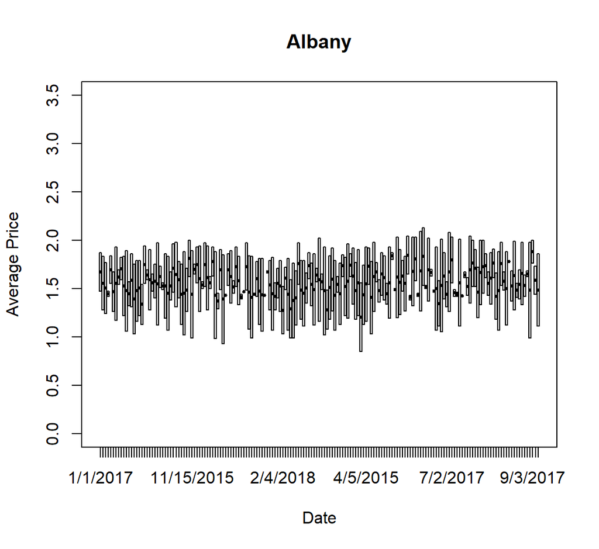

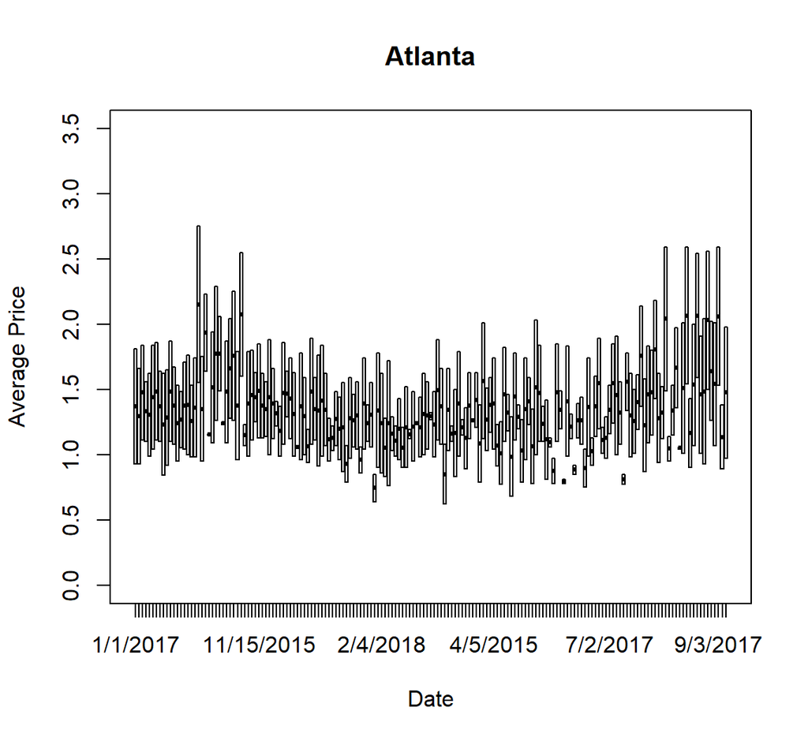

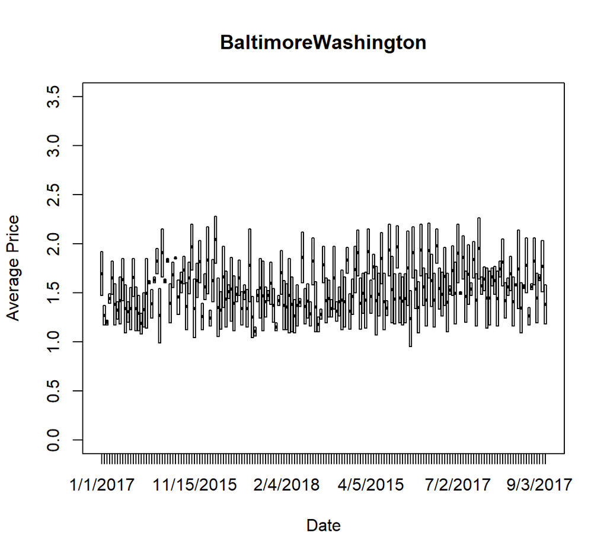

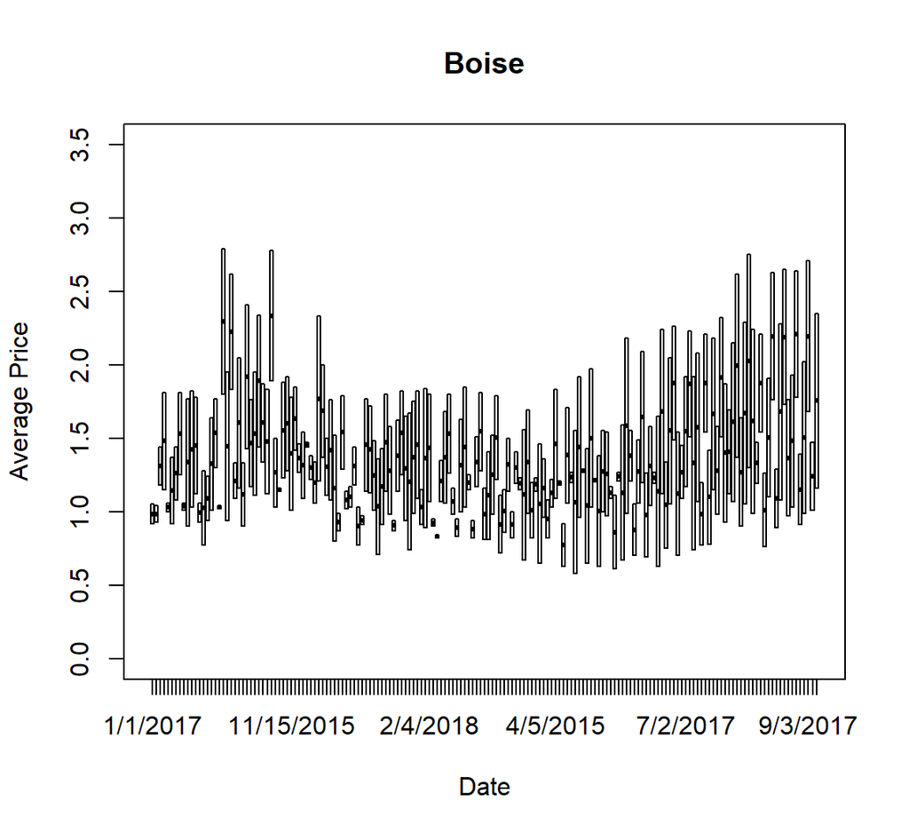

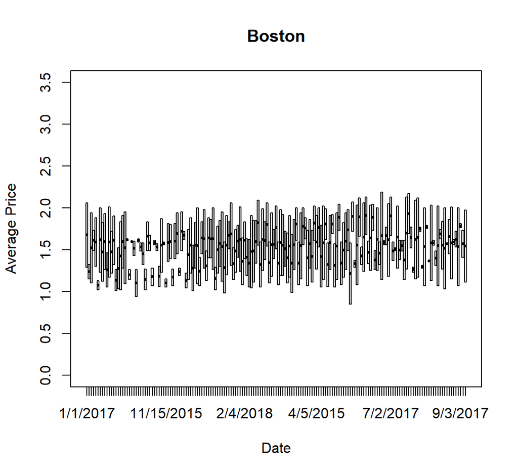

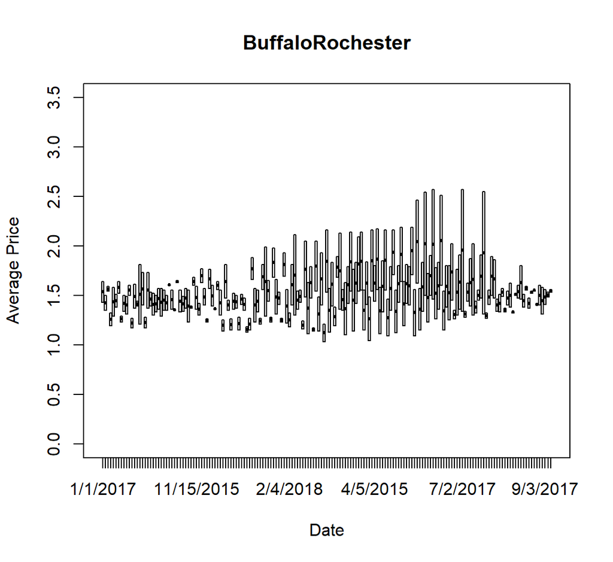

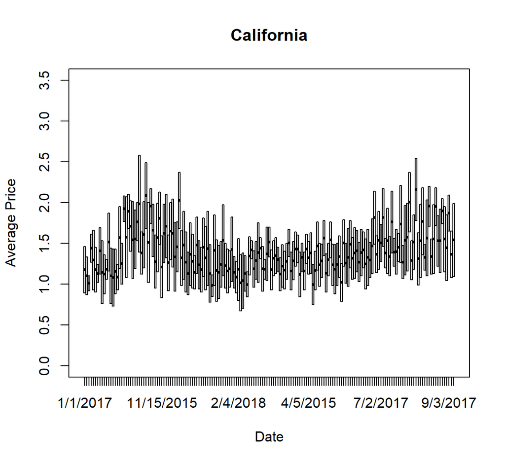

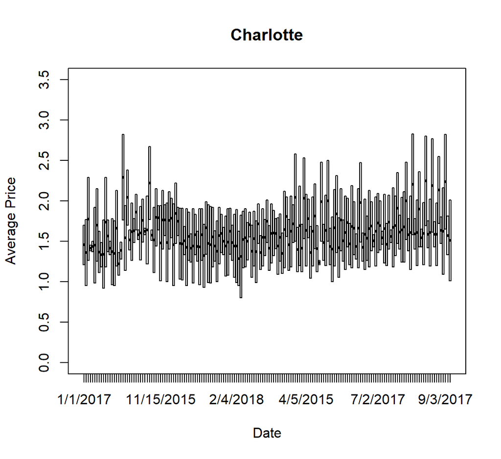

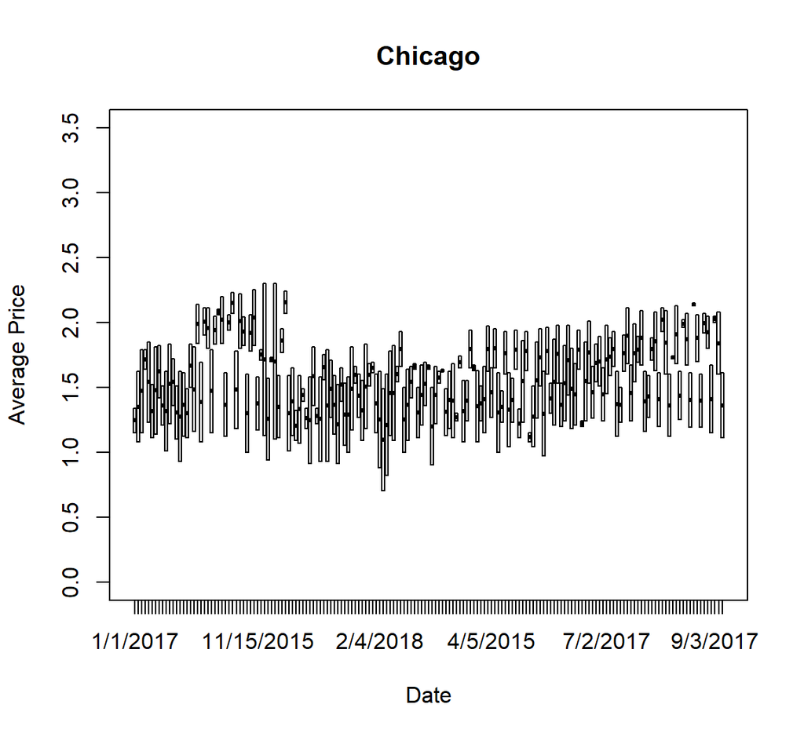

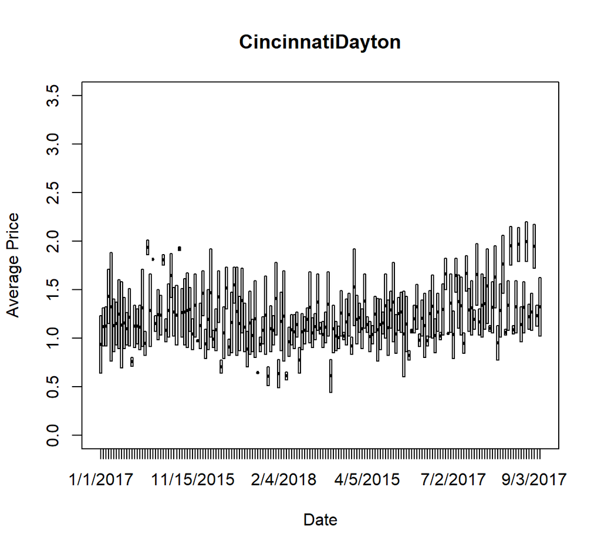

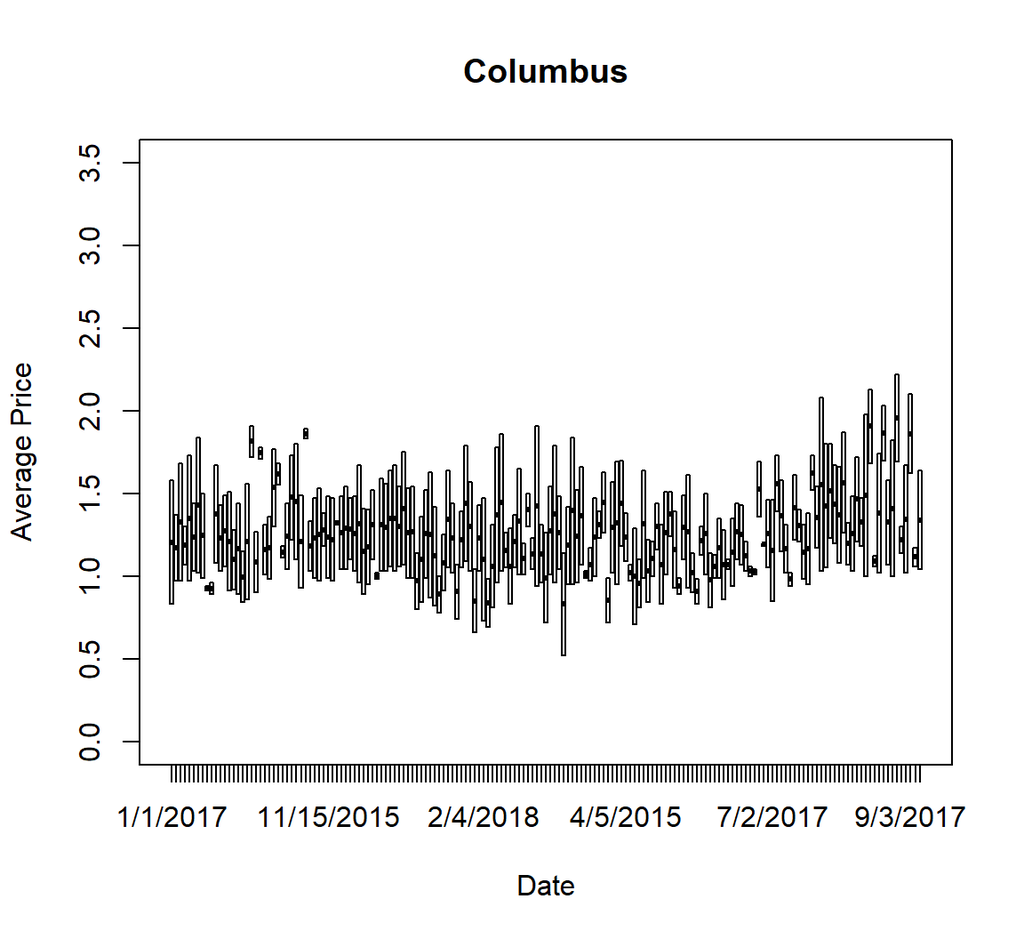

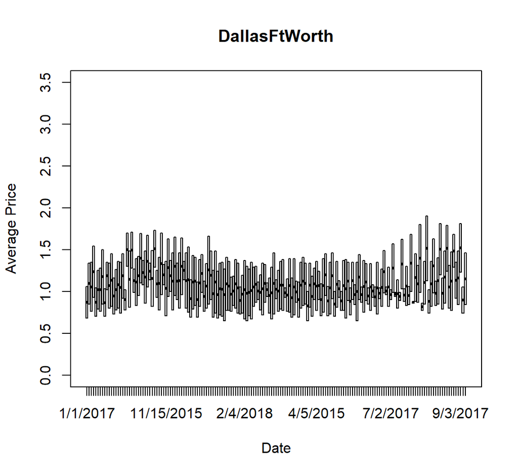

[42 more figures not shown]

```r
> for (i in unique(avo$region)) {
+   tmp <- filter(avo, region == i)
+   plot(tmp$Date, tmp$AveragePrice, type = "b", main = i, xlab = "Date", ylab = "Average Price", ylim = c(0, 3.5))
+ }
```